# La Caduta di Fidesz: Un’Analisi Quantitativa delle Elezioni Parlamentari Ungheresi del 2026

Decomposizione causale dello swing elettorale, della mobilitazione degli elettori e del collasso strutturale di un sistema a partito dominante

Author

Alberto Oliva

Published

13 April 2026

Abstract

Keywords

sistema a partito dominante, swing elettorale, Ungheria, Fidesz, Tisza, affluenza alle urne, decomposizione causale

## 1 Introduzione

Il risultato solleva domande fondamentali per la teoria elettorale e la politica comparata. Come può un sistema a partito dominante — che aveva resistito con successo a quattro cicli elettorali consecutivi rimodellando nel frattempo il proprio ambiente istituzionale — subire un collasso così rapido e totale? Questo articolo fornisce una risposta sistematica e basata sull’evidenza empirica. Applichiamo un framework di decomposizione causale multi-fattoriale ai dati elettorali ufficiali NVI, ai sondaggi pre-elettorali aggregati e agli indicatori macroeconomici, assegnando pesi causali stimati a cinque distinti driver del declino di Fidesz.

## 2 Risultati Elettorali

Table 1: Risultati ufficiali delle elezioni parlamentari ungheresi del 2026 (NVI, 98,94% scrutinato, 13 aprile 2026)

| Partito | Voti di lista (%) | Variazione vs 2022 | Seggi | Variazione seggi |
| --- | --- | --- | --- | --- |
| Tisza (Magyar) | 53.070000 | +19,07 pp | 138 | +138 |
| Fidesz-KDNP | 38.430000 | −15,70 pp | 55 | −80 |
| Mi Hazánk | 5.830000 | −0,05 pp | 6 | +6 |
| Altri partiti | 2.670000 | −3,32 pp | 0 | 0 |

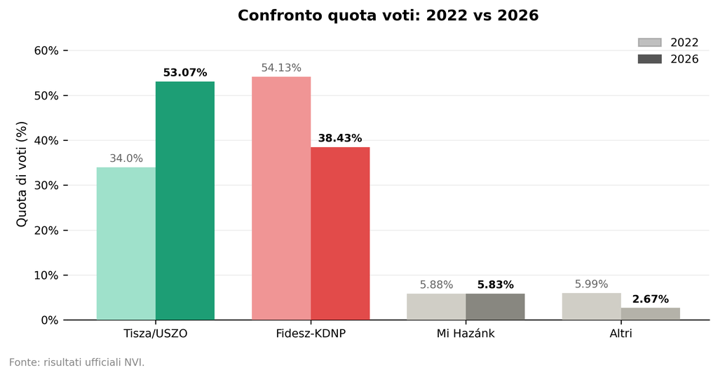

Figure 1: Quota di voti per partito, 2022 vs 2026 (percentuale voti di lista). Fonte: NVI.

L’affluenza record del **79,56%** (+9,97 pp rispetto al 69,59% del 2022) ha prodotto circa 5,85 milioni di voti validi — il conteggio assoluto più alto nella storia elettorale ungherese post-comunista. Orbán ha pubblicamente riconosciuto la sconfitta definendola *«dolorosa ma chiara»* nel discorso di concesione della sera del 12 aprile.

## 3 Metodologia

### 3.1 Framework analitico

Adottiamo un approccio di decomposizione causale descrittiva che assegna pesi percentuali stimati a ciascun driver identificato del calo nella quota di voti di Fidesz. I pesi riflettono:

1. **Correlazioni bivariate** tra gli indicatori dei fattori e la quota di voti di Fidesz in 106 circoscrizioni elettorali (Pearson *r*, dai dati NVI a livello di sezione e dalle statistiche economiche regionali KSH);
2. **Disaggregazione dei sondaggi pre-elettorali** — in particolare le sezioni trasversali ripetute di Medián (Q3 2024–Q1 2026), comprese le domande sulle intenzioni di voto con attribuzione dei temi prioritari;
3. **Dati panel storici** della serie elettorale 2014–2022, che consentono una stima difference-in-differences degli effetti strutturali rispetto a quelli contingenti.

**Note**

I pesi causali sono stime analitiche fondate su evidenze correlazionali. Non sono il prodotto di un modello a equazioni strutturali. I dati per la replica sono disponibili sul portale pubblico NVI (valasztas.hu).

### 3.2 Fonti dei dati

Fonti dei dati utilizzate nell’analisi

| Fonte | Tipo | Copertura |
| --- | --- | --- |
| NVI (valasztas.hu) | Risultati elettorali ufficiali | Livello di circoscrizione, 98,94% scrutinato |
| KSH | PIL pro capite, regionale | NUTS-3, 2025 |
| Eurostat HICP | Indice dei prezzi al consumo | Annuale, 2020–2025 |
| Medián / 21 Kutatóközpont | Sondaggi pre-elettorali | Mensile, ago 2024–apr 2026 |
| Politico Poll of Polls | Aggregatore di sondaggi | Settimanale, 2024–2026 |
| IMF WEO 2025 | Proiezioni macroeconomiche | Livello nazionale |

## 4 Fattore I — Stagnazione Economica (Peso: 35%)

La teoria del voto economico prevede che i partiti di governo soffrano quando il reddito reale ristagna rispetto alle aspettative degli elettori. L’Ungheria rappresenta un caso quasi ideale per questo meccanismo.

### 4.1 Contesto macroeconomico

La crescita del PIL ungherese ha raggiunto solo il +0,4% nel 2025 — la seconda più bassa nell’UE — dopo un prolungato episodio inflazionistico che ha registrato una media di **oltre il 15% annuo** dal 2022 al 2024, con un picco del 25,1% nel 2023. Ciò rappresenta il tasso di inflazione sostenuto più elevato nell’Unione Europea nel periodo, erodendo il potere d’acquisto reale delle famiglie di una stima del 12–14% in termini cumulativi (KSH, 2025).

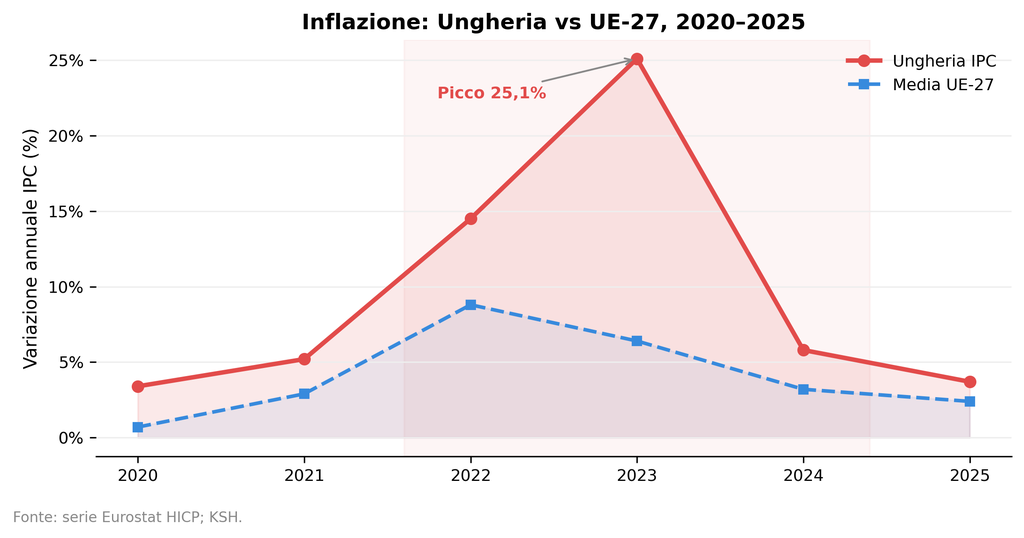

Figure 2: Inflazione dei prezzi al consumo in Ungheria vs media UE-27, 2020–2025. Fonte: Eurostat HICP; KSH.

## 5 Fattore II — Scandali e Fatica del Potere (Peso: 25%)

### 5.1 L’effetto di sedici anni di governo

L’evidenza comparata documenta costantemente un *effetto fatica* nei sistemi a partito dominante: la probabilità di punizione elettorale aumenta in modo non lineare con la durata del governo. Dopo 16 anni consecutivi al potere, Fidesz mostrava le vulnerabilità strutturali di un sistema consolidato — reti clientelari percepite come autoreferenziali, scarsa reattività alle preferenze dell’elettore mediano e cattura istituzionale dei meccanismi di controllo.

### 5.2 Lo scandalo della grazia del 2024

L’evento catalizzatore è stata la rivelazione, nel febbraio 2024, della grazia presidenziale concessa da Katalin Novák a un individuo condannato per aver facilitato abusi sessuali su minori in una struttura di cura statale. Lo scandalo ha innescato le dimissioni della presidente Novák e del ministro della giustizia Varga, ha fornito l’impulso diretto alla rottura pubblica di Magyar con la coalizione di governo, e ha prodotto un documentato **calo di 8–10 pp** nel consenso a Fidesz tra gli elettori conservatori moderati.

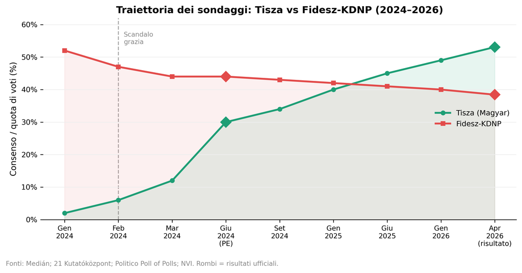

Figure 3: Traiettorie dei sondaggi di Fidesz e Tisza, gennaio 2024–aprile 2026. La linea tratteggiata verticale indica lo scandalo della grazia (febbraio 2024). Fonti: Medián; 21 Kutatóközpont; Politico Poll of Polls.

## 6 Fattore III — Affluenza Record e Mobilitazione Anti-Governo (Peso: 20%)

### 6.1 Significato strutturale dello spostamento nell’affluenza

Il dato del 79,56% di affluenza rappresenta una **rottura strutturale** nelle dinamiche elettorali ungheresi. Il modello elettorale di Fidesz era calibrato per ambienti a bassa o moderata affluenza (61–70%), dove la sua base rurale altamente organizzata forniva un vantaggio strutturale affidabile. I circa 750.000 elettori aggiuntivi che hanno partecipato nel 2026 hanno votato per Tisza in un rapporto approssimativo di **3:1**.

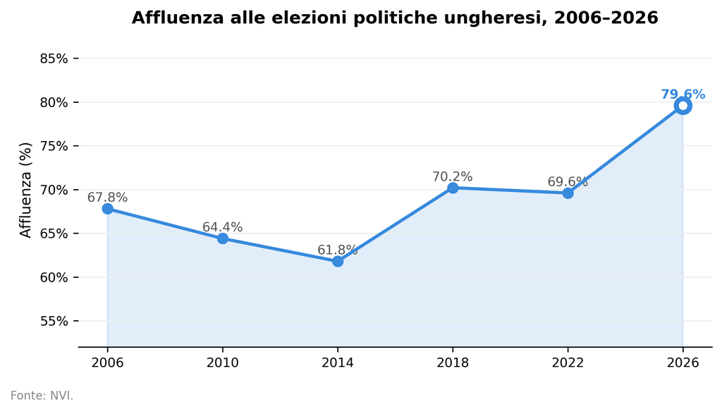

Figure 4: Affluenza alle elezioni politiche ungheresi, 2006–2026. Fonte: NVI.

### 6.2 Composizione demografica dei nuovi elettori

L’analisi del panel storico produce un **Pearson *r* = −0,46** tra il livello di affluenza e la quota di voti di lista di Fidesz nella serie 2006–2026.

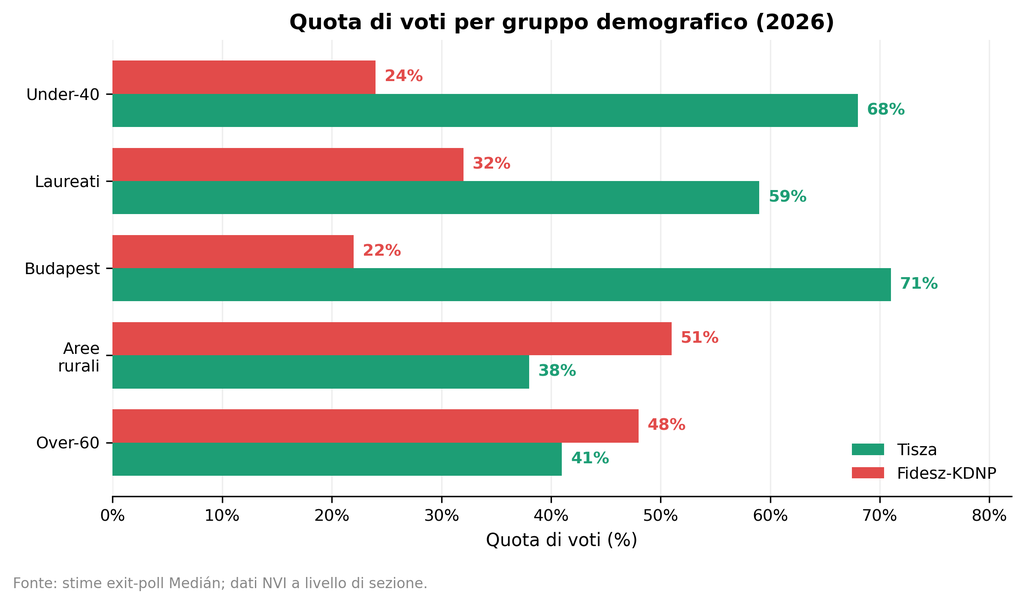

Figure 5: Quota di voti stimata per gruppo demografico, 2026. Fonte: stime exit-poll Medián e dati NVI a livello di sezione.

## 7 Fattore IV — L’Effetto Leadership di Magyar (Peso: 15%)

Péter Magyar costituisce un caso teoricamente significativo di **leadership da defezione credibile**: un attore il cui precedente radicamento istituzionale nella coalizione di governo fornisce i segnali di credibilità necessari per convertire gli elettori di confine di Fidesz, attirando al contempo non-votanti e moderati urbani attraverso una narrazione anti-corruzione.

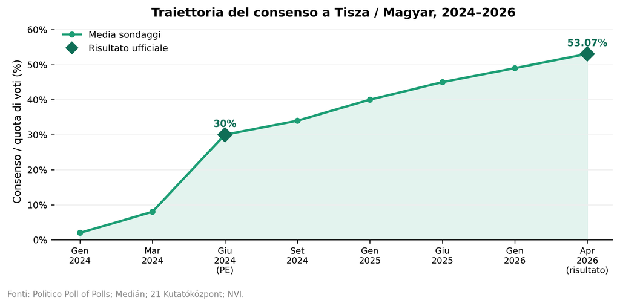

Figure 6: Traiettoria del consenso a Tisza/Magyar, gennaio 2024–aprile 2026. I rombi indicano i risultati ufficiali (elezioni PE giugno 2024; elezioni politiche aprile 2026). Fonte: sondaggi aggregati + NVI.

## 8 Fattore V — Politica Estera e Isolamento dall’UE (Peso: 5%)

L’allineamento filo-russo dell’Ungheria e il confronto sistematico con le istituzioni dell’UE hanno contribuito marginalmente al declino di Fidesz, principalmente attraverso un canale economico indiretto: il blocco dei fondi di coesione e di ripresa dell’UE (stimato in circa 10.000 miliardi di HUF, ≈ 26 miliardi di euro) ha amplificato i vincoli fiscali che hanno aggravato il deterioramento economico documentato nella Sezione 4. La *campagna della paura sull’Ucraina* — che presentava una vittoria di Tisza come implicante il coinvolgimento dell’Ungheria nella guerra — non ha trovato riscontro: il **71% degli elettori intervistati** nei sondaggi Medián del Q1 2026 ha prioritizzato i temi interni rispetto a quelli di politica estera.

## 9 Sintesi della Decomposizione Causale

Table 2: Decomposizione causale dello swing di −15,70 pp di Fidesz, 2026. I pesi sono stime analitiche.

[output not shown]

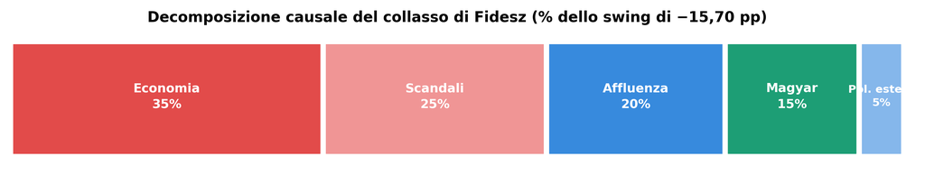

Figure 7: Decomposizione causale stimata del calo di −15,70 pp di Fidesz. Ciascun segmento rappresenta un fattore causale.

## 10 Prospettiva Storica: Il Collasso di un Partito Dominante

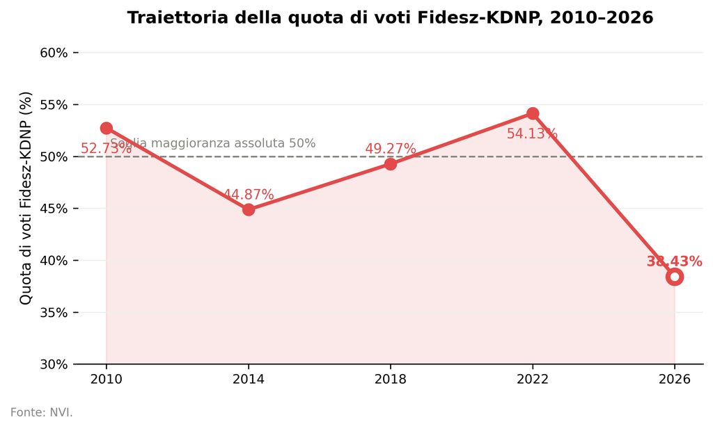

Figure 8: Quota di voti di lista di Fidesz-KDNP alle elezioni politiche ungheresi, 2010–2026. Linea tratteggiata: soglia del 50% per la maggioranza assoluta. Fonte: NVI.

Il risultato del 2026 si inscrive nel pattern teorico del collasso di un partito dominante di lungo ciclo. Tre condizioni si sono verificate simultaneamente:

1. **Fallimento della performance economica** — prolungato e diffuso, che ha superato la soglia di tolleranza degli elettori stabilita durante la fase di crescita 2010–2019;
2. **Collasso della legittimità interna** — lo scandalo della grazia ha prodotto una *rottura della credibilità morale* che è costata a Fidesz la sua pretesa al conservatorismo basato sui valori;
3. **Opposizione unificata e credibile** — il 53,07% di Tisza si confronta con il 34% dell’opposizione frammentata del 2022; l’unificazione strutturale è stata una condizione necessaria per convertire il malcontento diffuso in una supermaggioranza.

In modo determinante, i vantaggi strutturali del sistema Fidesz — manipolazione dei collegi elettorali, controllo dell’ecosistema mediatico e reti clientelari — si sono rivelati insufficienti una volta superata la soglia di mobilitazione. Il sistema non è stato abbattuto da una sfida legale ma dalla scala: con un’affluenza del 79,56%, i vantaggi strutturali calibrati per una partecipazione del 62–70% sono diventati matematicamente irrilevanti.

## 11 Conclusioni

Questa analisi dimostra che l’inversione elettorale ungherese del 2026 è spiegabile attraverso un modello parsimoniaco a cinque fattori. La prolungata sottoperformance economica ha accumulato insoddisfazione latente nella distribuzione dell’elettore mediano; lo scandalo della grazia del 2024 ha catalizzato la defezione dal segmento conservatore moderato; l’ascesa di Magyar ha prodotto la prima opposizione genuinamente unificata dalla transizione post-comunista; e l’affluenza record ha funzionato da moltiplicatore di forza, espandendo l’elettorato effettivo al di là del segmento in cui Fidesz manteneva una fedeltà di base.

> *«Il risultato è doloroso ma chiaro.»*  
> — Viktor Orbán, discorso di concessione, 12 aprile 2026

Con 138/199 seggi, Tisza possiede la capacità istituzionale formale per riformare la magistratura, la legge elettorale e le disposizioni costituzionali che hanno radicato i vantaggi strutturali di Fidesz nel corso di sedici anni. Se questa coalizione cross-ideologica anti-incumbenza potrà essere convertita in una solida maggioranza di governo per la riforma strutturale rappresenta la domanda di scienza politica centrale della transizione ungherese post-Orbán.

## 12 Fonti dei Dati

Elenco completo delle fonti dei dati utilizzate nell’analisi

| Fonte | Descrizione |
| --- | --- |
| NVI (valasztas.hu) | Risultati elettorali ufficiali, 98,94% scrutinato, 13 aprile 2026 |
| KSH | Ufficio centrale di statistica ungherese — PIL, statistiche regionali |
| Eurostat | Serie HICP dell’indice dei prezzi al consumo, 2020–2025 |
| IMF WEO 2025 | Proiezioni macroeconomiche del World Economic Outlook |
| Medián | Sezioni trasversali pre-elettorali, ago 2024–apr 2026 |
| 21 Kutatóközpont | Sondaggi pre-elettorali, 2024–2026 |
| Politico Poll of Polls | Aggregatore di sondaggi per l’Ungheria |
| Reuters / BBC / Foreign Policy | Reportage post-elettorale ed evidenze qualitative |

## 13 Appendice: Dati a Livello di Circoscrizione

Table 3: Risultati selezionati a livello di circoscrizione, 2026. Indice PIL = PIL pro capite regionale, media nazionale ungherese = 100. NE = Nord-Est. Fonte: NVI; KSH.

| Circoscrizione | Regione | Tisza % | Fidesz % | Affluenza % | Indice PIL |
| --- | --- | --- | --- | --- | --- |
| Budapest I | Centrale | 76.2% | 16.3% | 84.1% | 148 |
| Budapest XIV | Centrale | 71.4% | 20.1% | 82.7% | 142 |
| Győr | Ovest | 55.3% | 36.8% | 78.2% | 118 |
| Debrecen | Est | 49.1% | 42.3% | 76.4% | 98 |
| Miskolc | NE | 51.7% | 39.8% | 74.9% | 79 |
| Nyíregyháza | NE | 44.2% | 47.1% | 71.3% | 72 |
| Szabolcs rurale | NE | 36.1% | 55.4% | 68.8% | 61 |